# Exploring Kriging Models for Interpolating NO2 Values

-D.G.P. Madhushanka (MSC-DSA-098)

# 1 Methodology

Our analysis initiated with the thorough exploration and preparation of the NO2 dataset using the necessary libraries, such as gstat, tidyverse, and others, ensuring data integrity and compatibility for subsequent analysis. This involved transforming the dataset into a spatial sf object and preprocessing administrative boundary data for spatial mapping and visualization purposes, thus laying a solid foundation for spatial analysis.

Following data preparation, we delved into the application of two primary interpolation methods: Inverse Distance Weighting (IDW) and Kriging. IDW provided an initial estimation of NO2 values across the study area, offering a straightforward approach based on the weighted average of nearby observed values. However, recognizing the limitations of IDW, we proceeded to conduct variogram analysis to gain deeper insights into the spatial autocorrelation structure of NO2 concentrations.

The culmination of our analysis involved the visual comparison of interpolated NO2 values obtained from both IDW and kriging methods. This comparative analysis, informed by variogram insights, provided valuable feedback on the performance and reliability of each interpolation technique. By evaluating the spatial distribution and patterns of interpolated values, we gained deeper understanding and confidence in the efficacy of the chosen interpolation methods for NO2 concentration estimation in the study area.

# 2 Data Preparation

## 2.1 load libraries

Using essential spatial analysis libraries for NO2 interpolation: gstat, tidyverse, viridis, sf, stars, and patchwork

```r
library(gstat)
library(tidyverse)
library(viridis)
library(sf)
library(stars)
library(patchwork)
```

## 2.2 Load dataset.

Reading NO2 data from CSV file using gstat package’s built-in dataset loader.

```r
no2 <- read_csv(system.file("external/no2.csv",
                            package = "gstat"), show_col_types = FALSE)
```

## 2.3 explore dataset

Displaying the first three rows of the ‘no2’ dataset to get a quick overview of NO2 values

```r
head(data.frame(no2), 3)
```

```
##   station_european_code station_local_code country_iso_code country_name
## 1               DENI063            DENI063               DE      Germany
## 2               DEBY109            DEBY109               DE      Germany
## 3               DEBE056            DEBE056               DE      Germany
##         station_name station_start_date station_end_date type_of_station
## 1         Altes Land         1999-02-11               NA      Background
## 2 Andechs/Rothenfeld         2003-04-17               NA      Background
## 3  B Friedrichshagen         1994-02-01               NA      Background
##   station_ozone_classification station_type_of_area station_subcat_rural_back
## 1                        rural                rural                   unknown
## 2                        rural                rural                  regional
## 3                        rural                rural                 near city
##   street_type station_longitude_deg station_latitude_deg station_altitude
## 1        <NA>              9.685031             53.52418                3
## 2        <NA>             11.220172             47.96875              700
## 3        <NA>             13.647050             52.44770               35
##   station_city lau_level1_code lau_level2_code lau_level2_name EMEP_station
## 1         <NA>              NA         3359028            Jork           no
## 2         <NA>              NA         9188117         Andechs           no
## 3         <NA>              NA        11000000   Berlin, Stadt           no
##         NO2
## 1 13.102806
## 2  7.135128
## 3 12.799011
```

## 2.4 change geom coodinates.

Transforming the ‘no2’ dataset into a spatial sf object with CRS set to EPSG:32632 for further geographic analysis

```r
crs <- st_crs("EPSG:32632")
no2.sf <- st_as_sf(no2, crs = "OGC:CRS84", coords =
                     c("station_longitude_deg", "station_latitude_deg")) |>
  st_transform(crs)
no2.sf
```

```
## Simple feature collection with 74 features and 19 fields
## Geometry type: POINT
## Dimension:     XY
## Bounding box:  xmin: 304638.2 ymin: 5263687 xmax: 900829.7 ymax: 6086661
## Projected CRS: WGS 84 / UTM zone 32N
## # A tibble: 74 × 20
##    station_european_code station_local_code country_iso_code country_name
##  * <chr>                 <chr>              <chr>            <chr>
##  1 DENI063               DENI063            DE               Germany
##  2 DEBY109               DEBY109            DE               Germany
##  3 DEBE056               DEBE056            DE               Germany
##  4 DEBE062               DEBE062            DE               Germany
##  5 DEBE032               DEBE032            DE               Germany
##  6 DEHE046               DEHE046            DE               Germany
##  7 DEBY122               DEBY122            DE               Germany
##  8 DESL019               DESL019            DE               Germany
##  9 DENW081               DENW081            DE               Germany
## 10 DESH008               DESH008            DE               Germany
## # ℹ 64 more rows
## # ℹ 16 more variables: station_name <chr>, station_start_date <date>,
## #   station_end_date <lgl>, type_of_station <chr>,
## #   station_ozone_classification <chr>, station_type_of_area <chr>,
## #   station_subcat_rural_back <chr>, street_type <chr>, station_altitude <dbl>,
## #   station_city <chr>, lau_level1_code <dbl>, lau_level2_code <dbl>,
## #   lau_level2_name <chr>, EMEP_station <chr>, NO2 <dbl>, …
```

## 2.5 Read and transform spatial data, then plot it

Visualizing spatial data overlaid with NO2 concentrations on a map after transforming the coordinate reference system

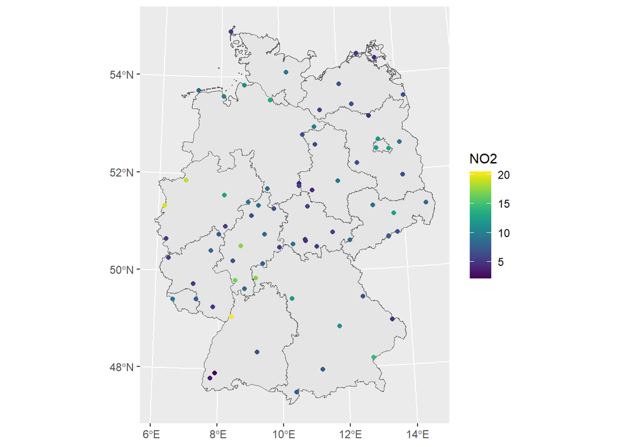

```r
map <- read_sf("de_nuts1.gpkg") |> st_transform(crs)

ggplot() + geom_sf(data = map) +
  geom_sf(data = no2.sf, mapping = aes(col = NO2)) +
  scale_color_viridis()
```

## 2.6 Prepare grid.

# 3 IDW Interpolation.

### 3.0.1 Grid preperation

Creating a grid based on the bounding box of the map, converting it to stars format with a cell size of 10,000, and then cropping it to match the map extent

```r
grid <- st_bbox(map) |>
  st_as_stars(dx = 10000) |> st_crop(map)
grid
```

```
## stars object with 2 dimensions and 1 attribute
## attribute(s):
##         Min. 1st Qu. Median Mean 3rd Qu. Max. NA's
## values     0       0      0    0       0    0 2076
## dimension(s):
##   from to  offset  delta                refsys x/y
## x    1 65  280741  10000 WGS 84 / UTM zone 32N [x]
## y    1 87 6101239 -10000 WGS 84 / UTM zone 32N [y]
```

## 3.1 Plot interpolated values

Performing Inverse Distance Weighting (IDW) interpolation on NO2 data to estimate values across the grid, visualizing the interpolated values overlaid on the map alongside original data points

```r
interpolated.values <- idw(NO2~1, no2.sf, grid)
```

```
## [inverse distance weighted interpolation]
```

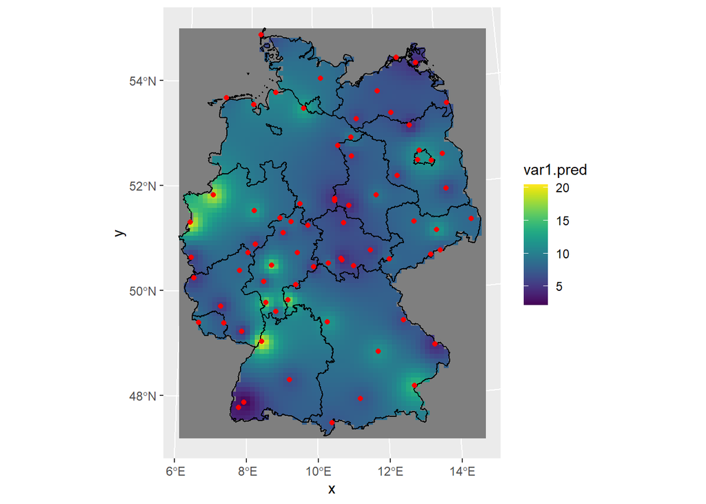

```r
ggplot() + geom_stars(data = interpolated.values,
                      aes(fill = var1.pred, x = x, y = y)) +
  geom_sf(data = st_cast(map, "MULTILINESTRING")) +
  geom_sf(data = no2.sf, col="red") + scale_fill_viridis()
```

Side-by-side comparison of NO2 concentrations on a map using ggplot2, showcasing original data points and interpolated values.”

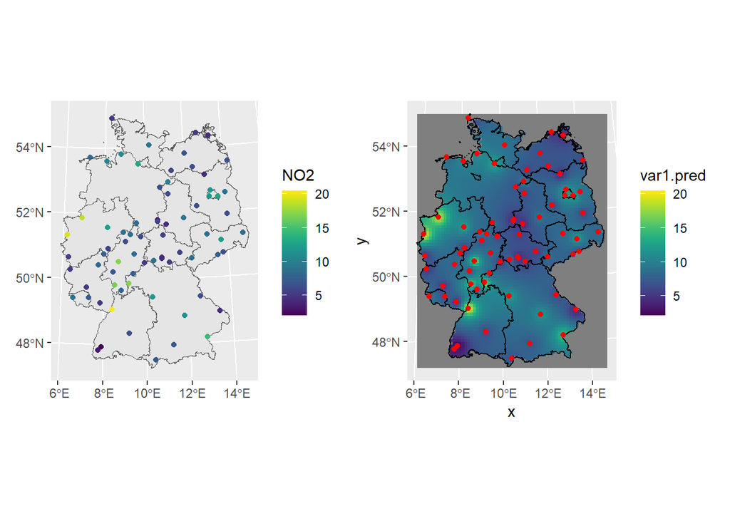

```r
p1 <- ggplot() + geom_sf(data = map) +  geom_sf(data = no2.sf, mapping = aes(col = NO2)) + scale_color_viridis()
p2 <- ggplot() + geom_stars(data = interpolated.values,
                            aes(fill = var1.pred, x = x, y = y)) + geom_sf(data = st_cast(map, "MULTILINESTRING")) + geom_sf(data = no2.sf, col="red") + scale_fill_viridis()
p1|p2
```

# 4 Ordinary Kriging

## 4.1 Variogram creation

Creating a variogram cloud to analyze spatial autocorrelation of NO2 concentrations.

```r
vcloud <- variogram(NO2~1, no2.sf, cloud=TRUE)
```

## 4.2 plot the variogram.

Generating a variogram with a specified cutoff distance and width, visualizing spatial autocorrelation of NO2 concentrations.

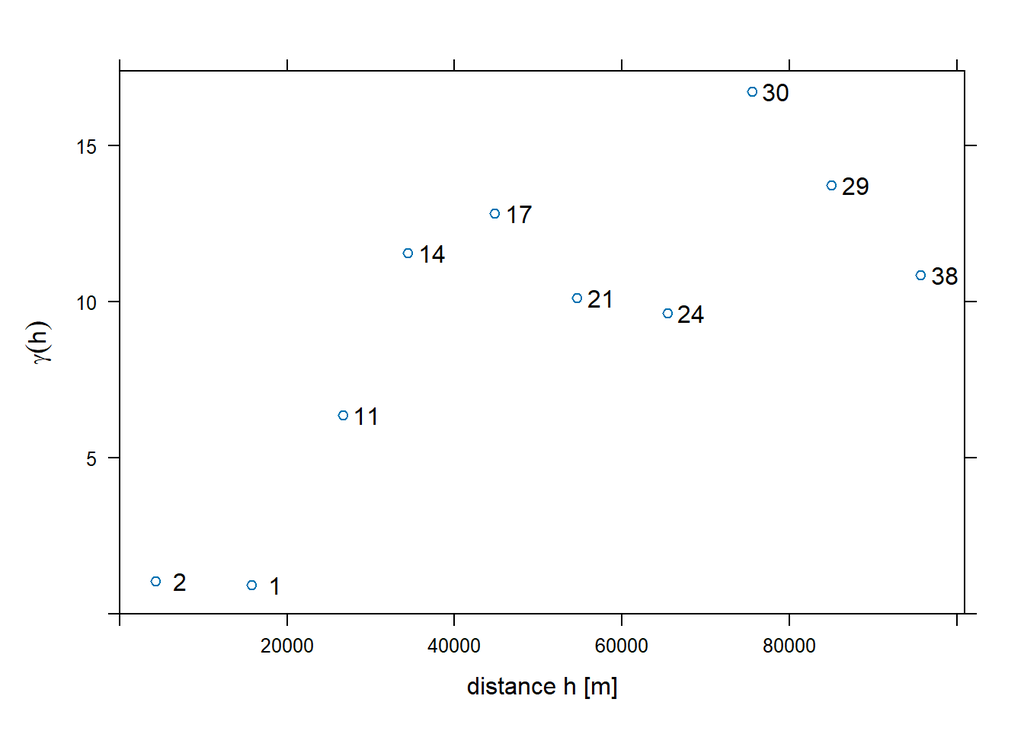

```r
v2 <- variogram(NO2~1, no2.sf, cutoff = 100000, width = 10000)
plot(v2, plot.numbers = TRUE, xlab = "distance h [m]",
     ylab = expression(gamma(h)),
     xlim = c(0, 1.055 * max(v2$dist)))
```

## 4.3 variogram values.

Listing available variogram models for fitting.

```r
vgm()
```

```
##    short                                      long
## 1    Nug                              Nug (nugget)
## 2    Exp                         Exp (exponential)
## 3    Sph                           Sph (spherical)
## 4    Gau                            Gau (gaussian)
## 5    Exc        Exclass (Exponential class/stable)
## 6    Mat                              Mat (Matern)
## 7    Ste Mat (Matern, M. Stein's parameterization)
## 8    Cir                            Cir (circular)
## 9    Lin                              Lin (linear)
## 10   Bes                              Bes (bessel)
## 11   Pen                      Pen (pentaspherical)
## 12   Per                            Per (periodic)
## 13   Wav                                Wav (wave)
## 14   Hol                                Hol (hole)
## 15   Log                         Log (logarithmic)
## 16   Pow                               Pow (power)
## 17   Spl                              Spl (spline)
## 18   Leg                            Leg (Legendre)
## 19   Err                   Err (Measurement error)
## 20   Int                           Int (Intercept)
```

## 4.4 check all variogram for find a mapping.

Displaying a visual representation of available variogram models for fitting, with adjusted text size.

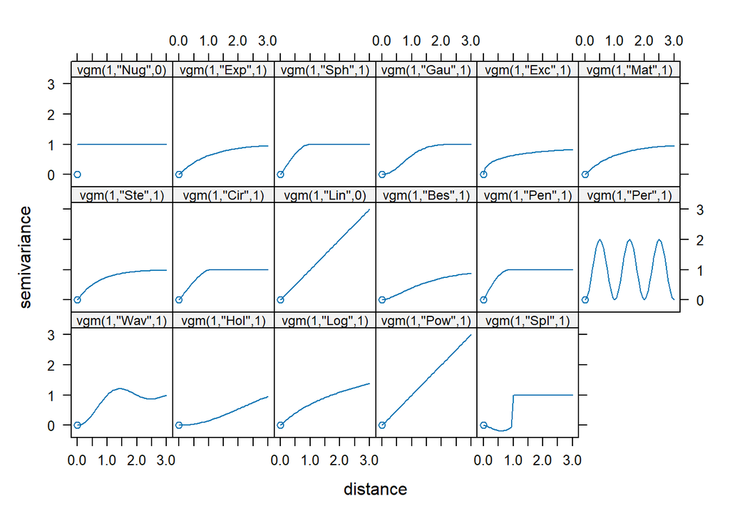

```r
show.vgms(par.strip.text=list(cex=0.75))
```

## 4.5 fit the variogram.

Fitting an exponential variogram model to the empirical variogram and visualizing the fit.

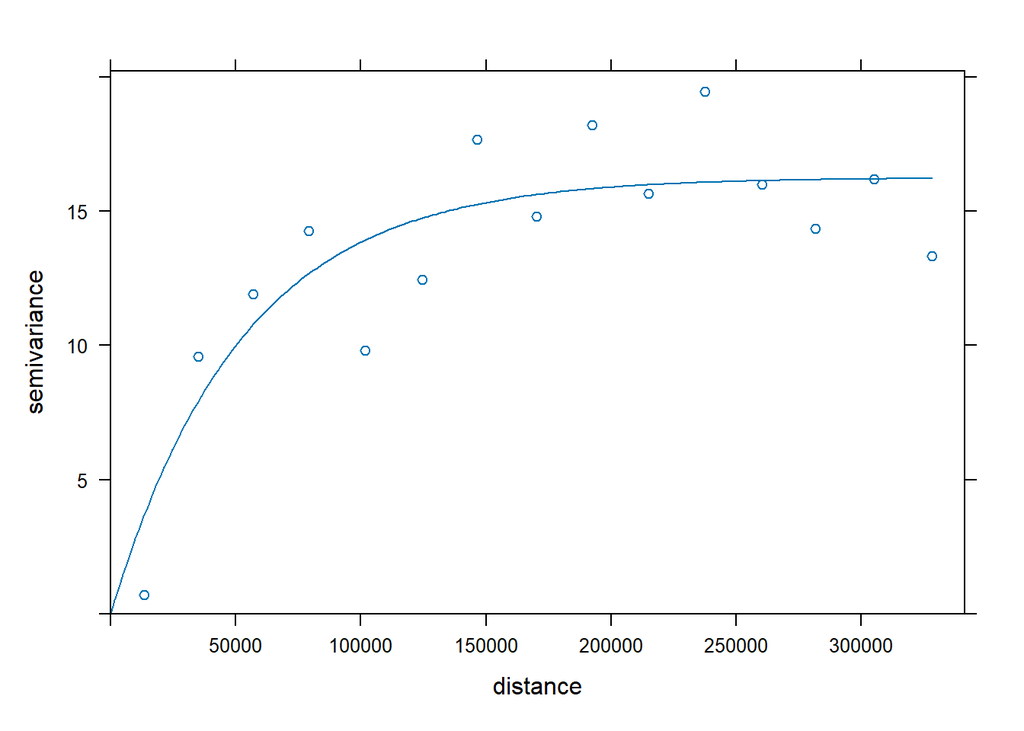

```r
v1 <- variogram(NO2~1, no2.sf)
v.m <- fit.variogram(v1, vgm(psill=20, model = "Exp", range = 20000, nugget = 1))
plot(v1, v.m)
```

## 4.6 check for isotropiness

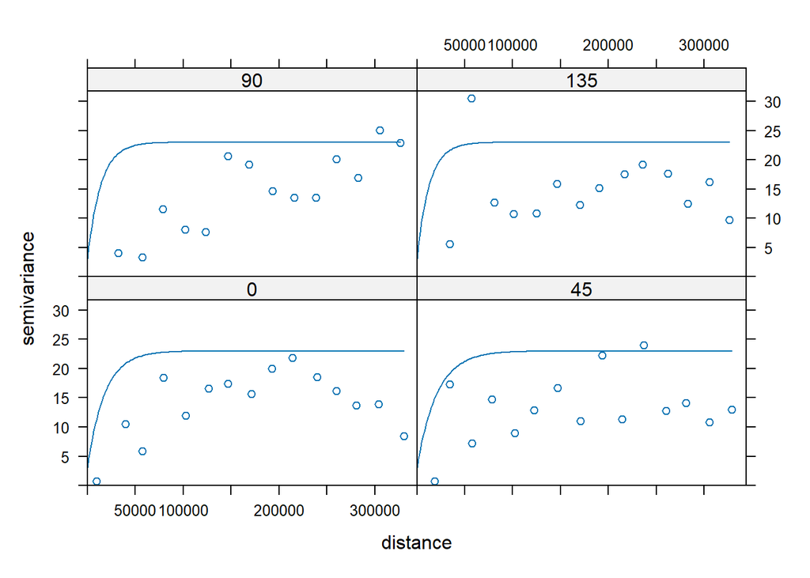

```r
v1.ani <- variogram(NO2~1, alpha = c(0, 45, 90, 135), no2.sf)
fit.ani <- vgm(psill=20, model = "Exp", range = 25000, nugget = 3, anis = c(30, 10, 0, 0.5, 0.3))
plot(v1.ani, fit.ani)
```

## 4.7 krigging.

```r
krigOK <- krige(NO2~1, no2.sf, grid, v.m)
```

```
## [using ordinary kriging]
```

## 4.8 plot the interpolated values with krigin.

Visualizing interpolated NO2 concentrations using kriging overlaid on the map with original data points

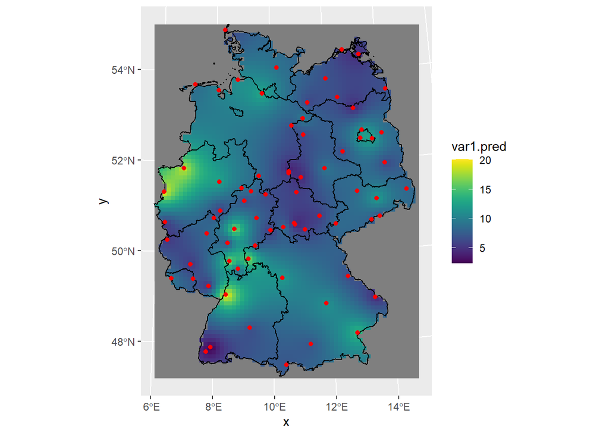

```r
ggplot() + geom_stars(data =krigOK,
                      aes(fill = var1.pred, x = x, y = y)) +
  geom_sf(data = st_cast(map, "MULTILINESTRING")) +
  geom_sf(data = no2.sf, col="red") + scale_fill_viridis()
```

## 4.9 Validation-Cross validation and RMSE.

```r
krig.ok.cv <- krige.cv(NO2~1, no2.sf, v.m)
krig.ok.cv
```

```
## Simple feature collection with 74 features and 6 fields
## Geometry type: POINT
## Dimension:     XY
## Bounding box:  xmin: 304638.2 ymin: 5263687 xmax: 900829.7 ymax: 6086661
## Projected CRS: WGS 84 / UTM zone 32N
## First 10 features:
##    var1.pred  var1.var  observed    residual      zscore fold
## 1   9.064467 14.151031 13.102806  4.03833865  1.07351642    1
## 2   9.074518 15.283772  7.135128 -1.93938966 -0.49607780    2
## 3  10.187623  7.825023 12.799011  2.61138737  0.93353044    3
## 4  10.291637  7.796963 11.830894  1.53925685  0.55124968    4
## 5  10.992385  7.354472 11.980110  0.98772545  0.36421725    5
## 6   8.689390  8.426194  8.935611  0.24622086  0.08482212    6
## 7   8.013070 15.678342  7.020690 -0.99238068 -0.25062722    7
## 8   7.132927 13.703602  9.226796  2.09386890  0.56562958    8
## 9  11.392578 15.191786 18.700023  7.30744545  1.87482686    9
## 10  9.252903 15.106029  9.159836 -0.09306688 -0.02394528   10
##                    geometry
## 1  POINT (545413.7 5930802)
## 2  POINT (665710.6 5315213)
## 3  POINT (815741.2 5820995)
## 4  POINT (790544.1 5842367)
## 5  POINT (786923.1 5822067)
## 6  POINT (495006.7 5697747)
## 7  POINT (605720.5 5263687)
## 8  POINT (322457.1 5476682)
## 9  POINT (353646.6 5747825)
## 10 POINT (581136.7 5994606)
```

## 4.10 RMSE in Ordinary Kriging.

```r
rmseOK <- round(sqrt(mean(krig.ok.cv$residual^2)), 2)
rmseOK
```

```
## [1] 3.87
```

# 5 Regression Kriging

## 5.1 Relationship identification

With below graph we can identified there is a liner relationship with NO2 with station_altitude.

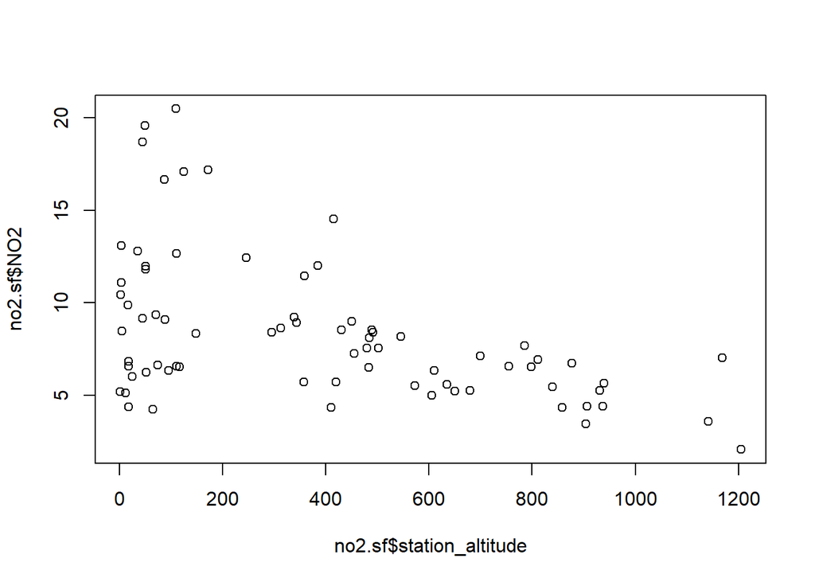

```r
plot( no2.sf$station_altitude, no2.sf$NO2)
```

## 5.2 Fit Variogram

we plot the variogram for above identified pattern.

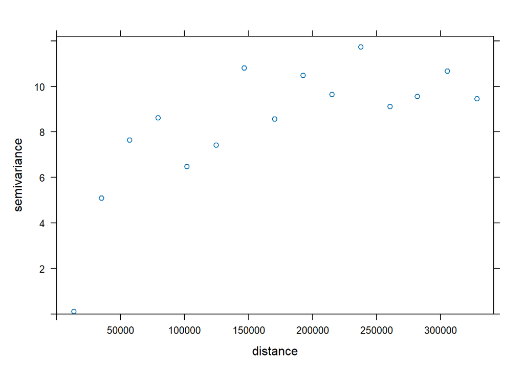

```r
v.rk <- variogram(NO2~station_altitude, no2.sf)
plot(v.rk)
```

## 5.3 Isotropy assumption

Below variogram matches in the directions of 0, 45, 90, and 135 degrees, and it’s safe to assume that the variation is constant in all directions, then we can conclude that there is isotropy. Therefore, we can proceed with modeling using kriging.

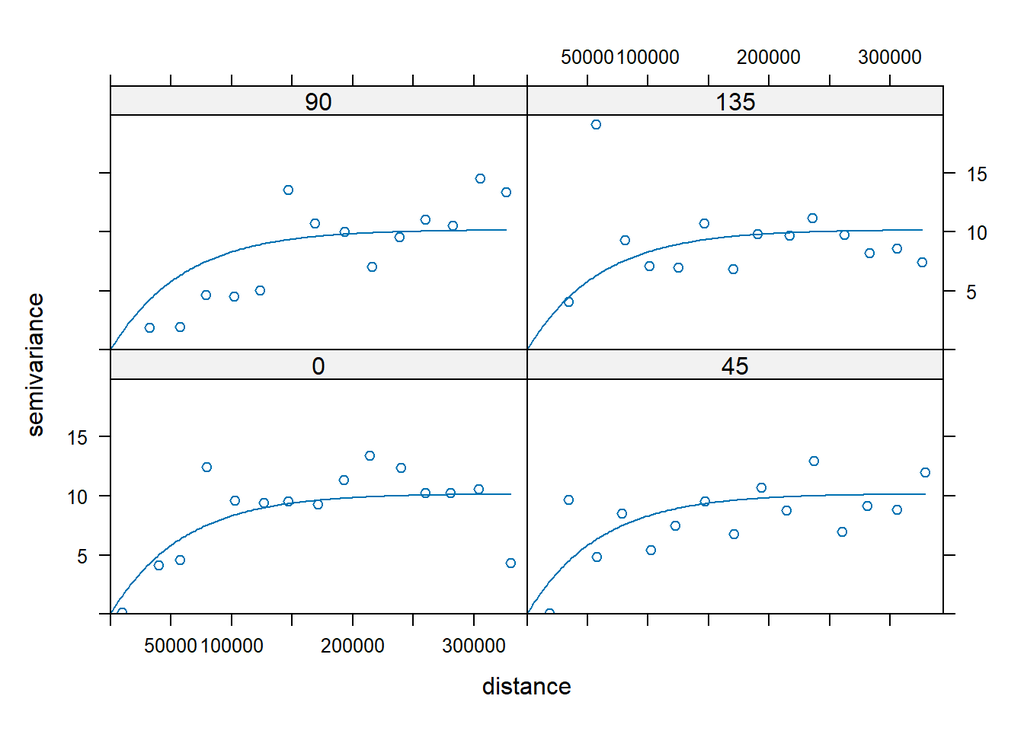

```r
v1.ani.rk <- variogram(NO2~station_altitude, alpha = c(0, 45, 90, 135), no2.sf)
v.m.rk <- fit.variogram(v1.ani.rk, vgm(psill=15, model = "Exp", range = 20000, nugget = 1))
plot(v1.ani.rk, v.m.rk)
```

## 5.4 Kriging width Regression

As the model is isotropy and we apply that Regression and do the kriging for interpolation

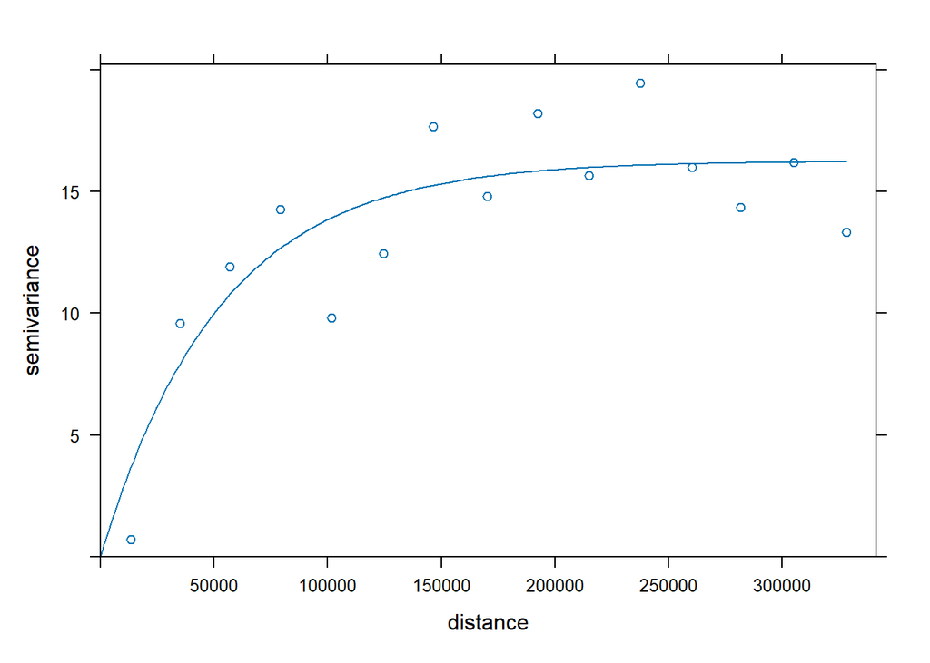

```r
v.m.rk <- fit.variogram(v.rk, vgm(psill=15, model = "Exp", range = 20000, nugget = 1))
plot(v1, v.m)
```

```r
krig.ok.cv <- krige.cv(NO2~station_altitude, no2.sf,v.m.rk)
```

## 5.5 Regression Kriging Validation

Here we got lesser RMSE than ordinary kriging. seem this interpolation more accureate than above kriging model.

RMSE in Regression Kriging:

```r
rmseRK <- round(sqrt(mean(krig.ok.cv$residual^2)), 2)
rmseRK
```

```
## [1] 2.97
```

# 6 Conclution

In conclusion, our exploration of Kriging interpolation, informed by variogram analysis, has yielded valuable insights into spatial modeling techniques for estimating NO2 concentrations. The meticulous data preparation process, which included transforming the dataset into spatial objects and conducting variogram analysis, laid a robust foundation for accurate interpolation.

In summary, this study underscores the significance of advanced spatial modeling techniques, particularly Kriging informed by variogram analysis, in environmental research. These methods provide a powerful framework for assessing air quality parameters like NO2 concentrations with greater accuracy and precision, enabling informed decision-making and policy formulation to address air pollution challenges effectively. Further we have validate our kriging models with RMSE values.

| Kriging Type | RMSE |
| --- | --- |
| Regression Kriging | 2.97 |
| Ordinary Kriging | 3.87 |

It seems that both Regression Kriging have relatively better than Ordinary Kriging as RMSE value is less in Regression Kriging. Therefore, we can assume that Regression Kriging methods good slitly better for spatial interpolation NO2 concentrations than Ordinary Kriging.